# R Ignite 2026 - Session 2: Interactive R Primer with NHANES

## 1. Import directly from a URL

```r
url <- "https://raw.githubusercontent.com/statOmics/PSLSData/main/NHANES.csv"
NHANES <- read.csv(url)
# Save as a CSV file
#write.csv(NHANES, file = "HANES_R_Ignite.csv", row.names = FALSE)
dim(NHANES)
```

```
## [1] 10000    76
```

```r
head(NHANES)
```

```
##      ID SurveyYr Gender Age AgeDecade AgeMonths Race1 Race3    Education
## 1 51624  2009_10   male  34     30-39       409 White  <NA>  High School
## 2 51624  2009_10   male  34     30-39       409 White  <NA>  High School
## 3 51624  2009_10   male  34     30-39       409 White  <NA>  High School
## 4 51625  2009_10   male   4       0-9        49 Other  <NA>         <NA>
## 5 51630  2009_10 female  49     40-49       596 White  <NA> Some College
## 6 51638  2009_10   male   9       0-9       115 White  <NA>         <NA>
##   MaritalStatus    HHIncome HHIncomeMid Poverty HomeRooms HomeOwn       Work
## 1       Married 25000-34999       30000    1.36         6     Own NotWorking
## 2       Married 25000-34999       30000    1.36         6     Own NotWorking
## 3       Married 25000-34999       30000    1.36         6     Own NotWorking
## 4          <NA> 20000-24999       22500    1.07         9     Own       <NA>
## 5   LivePartner 35000-44999       40000    1.91         5    Rent NotWorking
## 6          <NA> 75000-99999       87500    1.84         6    Rent       <NA>
##   Weight Length HeadCirc Height   BMI BMICatUnder20yrs   BMI_WHO Pulse BPSysAve
```

[output cut: 62 more lines]

```r
names(NHANES)
```

```
##  [1] "ID"               "SurveyYr"         "Gender"           "Age"
##  [5] "AgeDecade"        "AgeMonths"        "Race1"            "Race3"
##  [9] "Education"        "MaritalStatus"    "HHIncome"         "HHIncomeMid"
## [13] "Poverty"          "HomeRooms"        "HomeOwn"          "Work"
## [17] "Weight"           "Length"           "HeadCirc"         "Height"
## [21] "BMI"              "BMICatUnder20yrs" "BMI_WHO"          "Pulse"
## [25] "BPSysAve"         "BPDiaAve"         "BPSys1"           "BPDia1"
## [29] "BPSys2"           "BPDia2"           "BPSys3"           "BPDia3"
## [33] "Testosterone"     "DirectChol"       "TotChol"          "UrineVol1"
## [37] "UrineFlow1"       "UrineVol2"        "UrineFlow2"       "Diabetes"
## [41] "DiabetesAge"      "HealthGen"        "DaysPhysHlthBad"  "DaysMentHlthBad"
## [45] "LittleInterest"   "Depressed"        "nPregnancies"     "nBabies"
## [49] "Age1stBaby"       "SleepHrsNight"    "SleepTrouble"     "PhysActive"
## [53] "PhysActiveDays"   "TVHrsDay"         "CompHrsDay"       "TVHrsDayChild"
## [57] "CompHrsDayChild"  "Alcohol12PlusYr"  "AlcoholDay"       "AlcoholYear"
## [61] "SmokeNow"         "Smoke100"         "Smoke100n"        "SmokeAge"
## [65] "Marijuana"        "AgeFirstMarij"    "RegularMarij"     "AgeRegMarij"
## [69] "HardDrugs"        "SexEver"          "SexAge"           "SexNumPartnLife"
## [73] "SexNumPartYear"   "SameSex"          "SexOrientation"   "PregnantNow"
```

The expected raw dimensions are 10,000 rows and 76 columns. If the room network is unavailable, use a previously downloaded copy with `read.csv("NHANES.csv")`.

## 2. Inspect and create an adult person-level teaching dataset

```r
str(NHANES[c("ID","Gender","Age","Education","BMI","BPSysAve","Diabetes","HealthGen","PhysActive")])
```

```
## 'data.frame':    10000 obs. of  9 variables:
##  $ ID        : int  51624 51624 51624 51625 51630 51638 51646 51647 51647 51647 ...
##  $ Gender    : chr  "male" "male" "male" "male" ...
##  $ Age       : int  34 34 34 4 49 9 8 45 45 45 ...
##  $ Education : chr  "High School" "High School" "High School" NA ...
##  $ BMI       : num  32.2 32.2 32.2 15.3 30.6 ...
##  $ BPSysAve  : int  113 113 113 NA 112 86 107 118 118 118 ...
##  $ Diabetes  : chr  "No" "No" "No" "No" ...
##  $ HealthGen : chr  "Good" "Good" "Good" NA ...
##  $ PhysActive: chr  "No" "No" "No" NA ...
```

```r
sum(duplicated(NHANES$ID))
```

```
## [1] 3221
```

```r
dat <- NHANES[!duplicated(NHANES$ID), ]
dat <- subset(dat, Age >= 20)
dim(dat)
```

```
## [1] 4654   76
```

Note: keeping the first row per repeated ID is a workshop simplification. In substantive research, investigate the reason for repeated records before choosing a dduplication rule.

## 3. Missingness and descriptive statistics

```r
vars <- c("BMI","Gender","Diabetes","HealthGen","BPSysAve","Age","PhysActive")
sapply(dat[vars], function(x) sum(is.na(x)))
```

```
##        BMI     Gender   Diabetes  HealthGen   BPSysAve        Age PhysActive
##         45          0          1        521        194          0          0
```

```r
summary(dat$BMI)
```

```
##    Min. 1st Qu.  Median    Mean 3rd Qu.    Max.     NAs
##   15.02   24.20   27.80   28.90   32.22   81.25      45
```

```r
table(dat$Gender)
```

```
##
## female   male
##   2396   2258
```

```r
prop.table(table(dat$Diabetes))
```

```
##
##        No       Yes
## 0.8828713 0.1171287
```

```r
with(dat, tapply(BMI, Gender, mean, na.rm=TRUE))
```

```
##   female     male
## 29.16193 28.62637
```

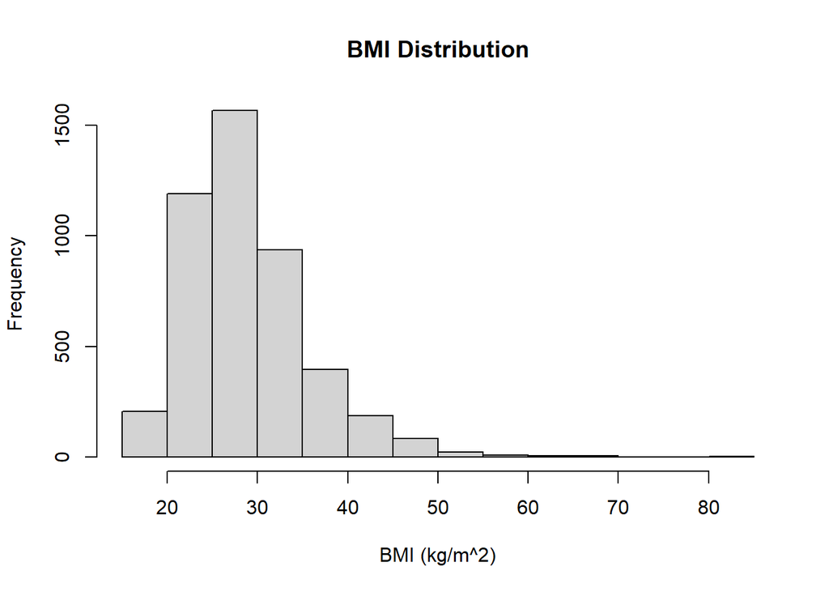

```r
hist(dat$BMI, main="BMI Distribution", xlab="BMI (kg/m^2)")
```

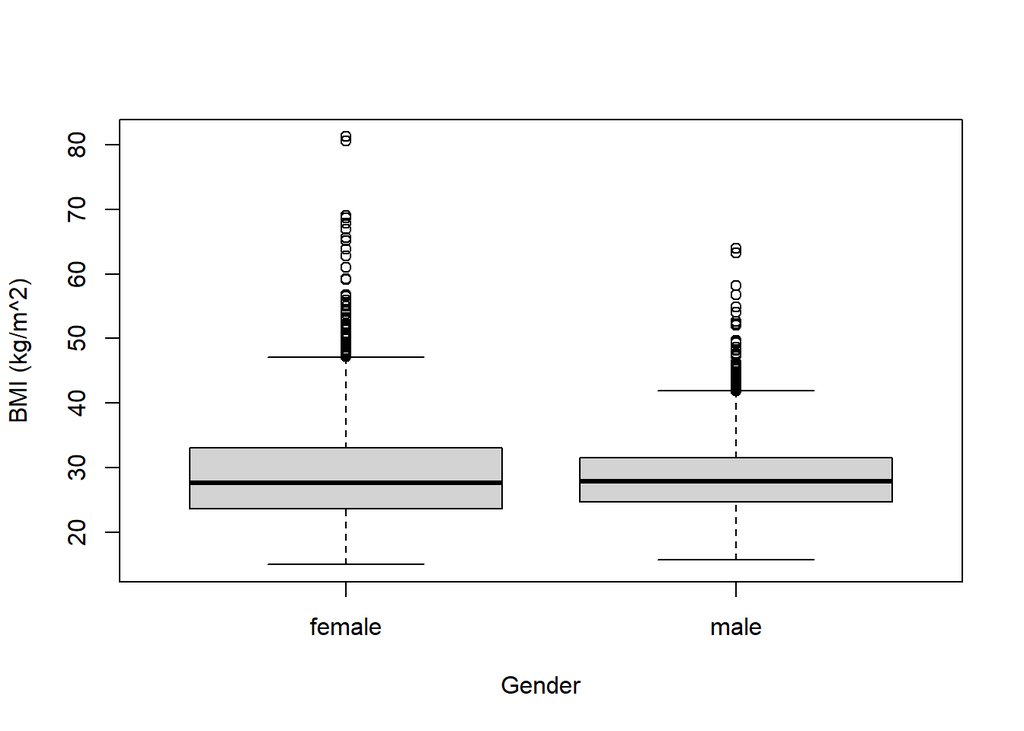

```r
boxplot(BMI ~ Gender, data=dat, xlab="Gender", ylab="BMI (kg/m^2)")
```

## 4. Welch two-sample t-test

Research question: Does mean BMI differ between gender groups?

- H0: the population mean BMI is equal in the two groups.
- H1: the population means differ.

```r
tt <- t.test(BMI ~ Gender, data=dat)
tt
```

```
##
##  Welch Two Sample t-test
##
## data:  BMI by Gender
## t = 2.6923, df = 4380.5, p-value = 0.007123
## alternative hypothesis: true difference in means between group female and group male is not equal to 0
## 95 percent confidence interval:
##  0.1455704 0.9255353
## sample estimates:
## mean in group female   mean in group male
##             29.16193             28.62637
```

```r
with(dat, tapply(BMI, Gender, mean, na.rm=TRUE))
```

```
##   female     male
## 29.16193 28.62637
```

## 5. Chi-square test of association

Research question: Is diabetes status associated with gender?

```r
tab <- with(dat, table(Gender, Diabetes, useNA="no"))
tab
```

```
##         Diabetes
## Gender     No  Yes
##   female 2130  265
##   male   1978  280
```

```r
prop.table(tab, margin=1)
```

```
##         Diabetes
## Gender          No       Yes
##   female 0.8893528 0.1106472
##   male   0.8759965 0.1240035
```

```r
chi <- chisq.test(tab)
chi
```

```
##
##  Pearson's Chi-squared test with Yates' continuity correction
##
## data:  tab
## X-squared = 1.8779, df = 1, p-value = 0.1706
```

```r
chi$expected
```

```
##         Diabetes
## Gender         No      Yes
##   female 2114.477 280.5233
##   male   1993.523 264.4767
```

## 6. One-way ANOVA

Research question: Does mean average systolic blood pressure differ across self-reported general-health categories?

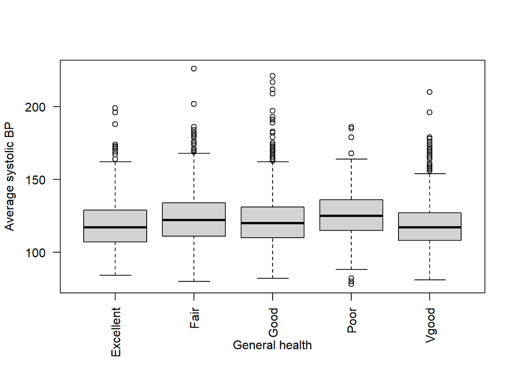

```r
anova_dat <- subset(dat, !is.na(BPSysAve) & !is.na(HealthGen))
anova_dat$HealthGen <- factor(anova_dat$HealthGen)
boxplot(BPSysAve ~ HealthGen, data=anova_dat, las=2,
        ylab="Average systolic BP", xlab="General health")
```

```r
fit_aov <- aov(BPSysAve ~ HealthGen, data=anova_dat)
summary(fit_aov)
```

```
##               Df  Sum Sq Mean Sq F value   Pr(>F)
## HealthGen      4   17230    4307   14.25 1.48e-11 ***
## Residuals   4042 1221505     302
## ---
## Signif. codes:  0 '***' 0.001 '**' 0.01 '*' 0.05 '.' 0.1 ' ' 1
```

```r
TukeyHSD(fit_aov)
```

```
##   Tukey multiple comparisons of means
##     95% family-wise confidence level
##
## Fit: aov(formula = BPSysAve ~ HealthGen, data = anova_dat)
##
## $HealthGen
##                       diff          lwr        upr     p adj
## Fair-Excellent   4.2631727   1.35302595  7.1733194 0.0006219
## Good-Excellent   2.5738636   0.04182414  5.1059031 0.0441327
## Poor-Excellent   7.4216074   2.80647714 12.0367376 0.0001142
## Vgood-Excellent -0.5075943  -3.11999355  2.1048050 0.9842646
## Good-Fair       -1.6893090  -3.90278182  0.5241637 0.2276793
## Poor-Fair        3.1584347  -1.28989813  7.6067675 0.2974590
## Vgood-Fair      -4.7707670  -7.07573284 -2.4658011 0.0000002
## Poor-Good        4.8477437   0.63705082  9.0584367 0.0145886
## Vgood-Good      -3.0814579  -4.88565793 -1.2772579 0.0000320
## Vgood-Poor      -7.9292017 -12.18870173 -3.6697016 0.0000039
```

### ANOVA diagnostics

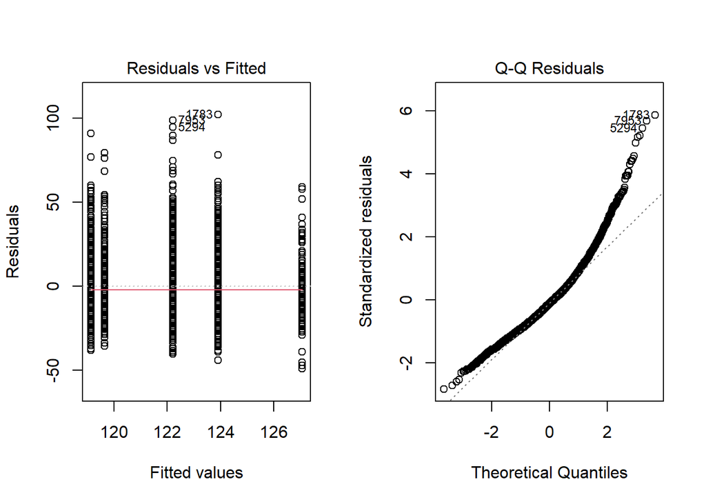

```r
par(mfrow=c(1,2))
plot(fit_aov, which=1)
plot(fit_aov, which=2)
```

```r
par(mfrow=c(1,1))
```

## 7. Logistic regression

Research question: How are age, BMI, gender and physical activity associated with the odds of diabetes?

```r
logit_dat <- subset(dat,
  !is.na(Diabetes) & !is.na(Age) & !is.na(BMI) &
  !is.na(Gender) & !is.na(PhysActive))

logit_dat$Diabetes01 <- ifelse(logit_dat$Diabetes == "Yes", 1, 0)
logit_dat$Gender <- factor(logit_dat$Gender)
logit_dat$PhysActive <- factor(logit_dat$PhysActive)

levels(logit_dat$Gender)
```

```
## [1] "female" "male"
```

```r
levels(logit_dat$PhysActive)
```

```
## [1] "No"  "Yes"
```

```r
table(logit_dat$Diabetes01)
```

```
##
##    0    1
## 4071  537
```

```r
fit_logit <- glm(Diabetes01 ~ Age + BMI + Gender + PhysActive,
                 data=logit_dat, family=binomial)
summary(fit_logit)
```

```
##
## Call:
## glm(formula = Diabetes01 ~ Age + BMI + Gender + PhysActive, family = binomial,
##     data = logit_dat)
##
## Coefficients:
##                Estimate Std. Error z value Pr(>|z|)
## (Intercept)   -7.809490   0.346141 -22.562  < 2e-16 ***
## Age            0.056896   0.003261  17.446  < 2e-16 ***
## BMI            0.087145   0.006829  12.762  < 2e-16 ***
## Gendermale     0.358858   0.100303   3.578 0.000347 ***
## PhysActiveYes -0.208205   0.103569  -2.010 0.044399 *
## ---
## Signif. codes:  0 '***' 0.001 '**' 0.01 '*' 0.05 '.' 0.1 ' ' 1
##
## (Dispersion parameter for binomial family taken to be 1)
##
##     Null deviance: 3317.5  on 4607  degrees of freedom
## Residual deviance: 2772.8  on 4603  degrees of freedom
## AIC: 2782.8
##
## Number of Fisher Scoring iterations: 6
```

### Odds ratios and Wald 95% confidence intervals

```r
OR_table <- cbind(
  OR = exp(coef(fit_logit)),
  exp(confint.default(fit_logit))
)
colnames(OR_table) <- c("OR","2.5%","97.5%")
round(OR_table, 2)
```

```
##                 OR 2.5% 97.5%
## (Intercept)   0.00 0.00  0.00
## Age           1.06 1.05  1.07
## BMI           1.09 1.08  1.11
## Gendermale    1.43 1.18  1.74
## PhysActiveYes 0.81 0.66  0.99
```

## 8. Predicted probabilities

```r
new_people <- data.frame(
  Age=c(30,50,70),
  BMI=c(24,30,36),
  Gender=factor(c("female","female","female"), levels=levels(logit_dat$Gender)),
  PhysActive=factor(c("Yes","Yes","No"), levels=levels(logit_dat$PhysActive))
)
new_people$Pr_Diabetes <- predict(fit_logit, newdata=new_people, type="response")
new_people
```

```
##   Age BMI Gender PhysActive Pr_Diabetes
## 1  30  24 female        Yes  0.01449509
## 2  50  30 female        Yes  0.07185364
## 3  70  36 female         No  0.33412944
```

These are model-based teaching estimates, not clinical risk scores.

## 9. Extension track

```r
logit_dat$Age10 <- logit_dat$Age/10
fit_logit_10 <- glm(Diabetes01 ~ Age10 + BMI + Gender + PhysActive,
                    data=logit_dat, family=binomial)
exp(coef(fit_logit_10))
```

```
##   (Intercept)         Age10           BMI    Gendermale PhysActiveYes
##  0.0004058651  1.7664263707  1.0910546674  1.4316931893  0.8120401565
```

## 10. Exit questions

1. Why do we inspect and clean before hypothesis testing?
2. When would you choose a t-test, chi-square test, or ANOVA?
3. What does an odds ratio greater than 1 mean?
4. Why should this workshop analysis not be described as causal or as a population-weighted NHANES analysis?